# Concepts and Practices of Research Design for a Data Science Project

Author

Gargee Shah

Published

April 26, 2024

## Setup

If you have not installed the following packages, please install them before loading them.

```r
library(tidyverse)
library(readxl)
library(haven) #for loading other datafiles (SAS, STATA, SPSS, etc.)
library(stringr) # if you have not installed this package, please install it.
library(ggplot2) # if you have not installed this package, please install it.
```

## Project Overview

In this project, I will apply the knowledge about research design to the dataset presented.

## Part 1. Choose one of the following datasets to do a simple practice of research design and hypothesis testing (50%)

Dataset 1: The General Social Survey (2022). You can find more information about this data project at https://gss.norc.org/About-The-GSS. A codebook explaining the definition of each variable and column is also included.

Dataset 2: The Covid-19 Reports in Massachusetts. The datasets are stored in an Excel file of multiple sheets. You can find more information about this data project in the “Introduction”, “Definition”, “Notes”, and “Data Dictionary” tabs in the Excel file.

1. **Read the data you choose in R. (5%)**

   For GSS, there is only one data sheet (.dta).

   For the MA Covid-19 reports, you can choose **one of the four datasheets(tabs in Excel)** to read (“Weekly Cases and Deaths”, “Case and Death Demographics”, “County Data”, and “City and Town Data”).

   ```r
     #type your code here
     ma_covid19 <- read_xlsx('covid-19-dashboard-11-16-23.xlsx', sheet = "Weekly Cases and Deaths")
     head(ma_covid19)
   ```

   | Week Start Date | Week End Date | Confirmed deaths | Probable deaths | Confirmed and probable deaths | Confirmed cases | Probable cases | Confirmed and probable cases | Last updated |
   | --- | --- | --- | --- | --- | --- | --- | --- | --- |
   | 2023-01-08 | 2023-01-14 | 132 | 47 | 179 | 7075 | 1645 | 8720 | 2023-11-16 |
   | 2021-10-17 | 2021-10-23 | 79 | 4 | 83 | 8163 | 699 | 8862 | 2023-11-16 |
   | 2020-11-22 | 2020-11-28 | 153 | 15 | 168 | 18177 | 1003 | 19180 | 2023-11-16 |
   | 2021-10-03 | 2021-10-09 | 85 | 2 | 87 | 9316 | 748 | 10064 | 2023-11-16 |
   | 2020-04-05 | 2020-04-11 | 654 | 23 | 677 | 12145 | 30 | 12175 | 2023-11-16 |
   | 2021-04-25 | 2021-05-01 | 74 | 2 | 76 | 7105 | 924 | 8029 | 2023-11-16 |

2. **Answer the following questions.**

   (1) what is the structure (dimension) of the data? **(2.5%)**

   ```r
   #type your code here
   dim <- dim(ma_covid19)
   print(paste('# of Rows = ', dim[1]))
   ```

   ```
   [1] "# of Rows =  195"
   ```

   ```r
   print(paste('# of Columns = ', dim[2]))
   ```

   ```
   [1] "# of Columns =  9"
   ```

   (2) what is the unit of observation? **(2.5%)**

   Ans: The unit of observation is `the state of Massachusetts in a particular week between 2020 and 2023`. As, each row consists of per week information about number of cases and deaths due to covid-19 in Massachusetts.
3. **Read the overview introduction, codebook (for the GSS data), and other related information about the data (for the Covid-19 data). Now browse the data loaded in R, it seems like there are many different questions this data can answer. Based on the class lecture and KKV’s reading about “good research questions”, please propose ONE research question that can be answered using this data. (5%)**

   Ans: `Research Question`- What is the relationship between the number of confirmed deaths and the number of confirmed cases of COVID-19 in Massachusetts on a weekly basis?
4. **Based on the research question you proposed above, propose a hypothesis about a possible relationship between two items. (5%)**

   Ans: `Hypothesis`- I hypothesize that there is a positive relationship between the number of confirmed deaths and the number of confirmed cases. As the number of confirmed cases increases, the number of confirmed deaths will also increase and vice-versa.
5. **Based on the hypothesis proposed, please select variables/columns in the data to measure the corresponding concepts in the hypothesis statement. You should select at least one variable/column to measure each concept.**

   **You should also specify which variables/columns you choose and explain why they are the proper ones to measure the concepts. (10%)**

   **Instruction:** Don’t just answer, “They are reliable and valid”. Instead, you should discuss more why they are reliable (can consistently produce the same results regardless of the same results regardless different times and contexts) and valid (why it is better than other possible or alternative variables/columns). You can find the concepts of validity and reliability in the Nov 20 lecture and the slides (p23-25). There are also more in-depth introductions online, such as [this page](http://media.acc.qcc.cuny.edu/faculty/volchok/Measurement_Volchok/Measurement_Volchok6.html).

   Ans : Variables/Columns to Measure Concepts:
   - `Dependent Variable (DV)`: Number of Confirmed Deaths
   - `Independent Variable (IV)`: Number of Confirmed Cases

   Explanation of Reliability and Validity -
   - For `Confirmed Deaths`:
     - `Reliability`: The reliability of the “Confirmed deaths” variable can be justified by its consistent reporting over time. Deaths due to COVID-19 are typically accurately recorded, and this information is less likely to vary between different times and contexts.
     - `Validity`: The validity of the “Confirmed deaths” variable is supported by the fact that it directly measures the outcome of interest, which is the number of deaths attributed to COVID-19. This is a direct and accurate representation of the concept it intends to measure.
   - For `Confirmed Cases`:
     - `Reliability`: As per defination, consistent in producing the same results every time the measure is used. Hence, it is reliable because it consistently reports the number of confirmed COVID-19 cases over time.
     - `Validity`: Again, as per defination, it is measuring what is supposed to measure. Hence, it is valid as it directly measures the concept of interest, representing the spread of the virus in the population.
6. **Use the code we learned in the previous week to conduct descriptive statistics for the two variables/columns you selected above. You should present the following information in your descriptive statistics: range, average, standard deviation, the number of NAs, and the number of unique values. (5%)**

   ```r
   sum_stat <- function(x){
     stat <- tibble(
   range=range(x, na.rm = T),
   mean=mean(x, na.rm = T),
   sd=sd(x,na.rm=T),
   na = sum(is.na(x)),
   unique = length(unique(x))
     )
     return(stat)
   }
   ```

```r
    #type your code here
    sum_stat(ma_covid19$`Confirmed deaths`)
```

| range | mean | sd | na | unique |
| --- | --- | --- | --- | --- |
| 0 | 118.041 | 184.086 | 0 | 118 |
| 1210 | 118.041 | 184.086 | 0 | 118 |

```r
    sum_stat(ma_covid19$`Confirmed cases`)
```

| range | mean | sd | na | unique |
| --- | --- | --- | --- | --- |
| 1 | 10662.79 | 17876.93 | 0 | 194 |
| 162720 | 10662.79 | 17876.93 | 0 | 194 |

7. **Plot one univariate graph for each of the variables/columns. (5%)**

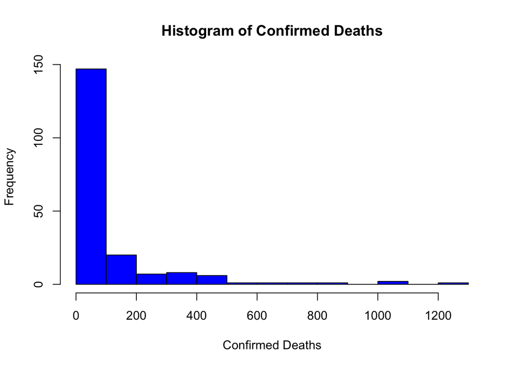

   ```r
   #type your code here
   hist(ma_covid19$`Confirmed deaths`, main = "Histogram of Confirmed Deaths", xlab = "Confirmed Deaths", col = "blue")
   ```

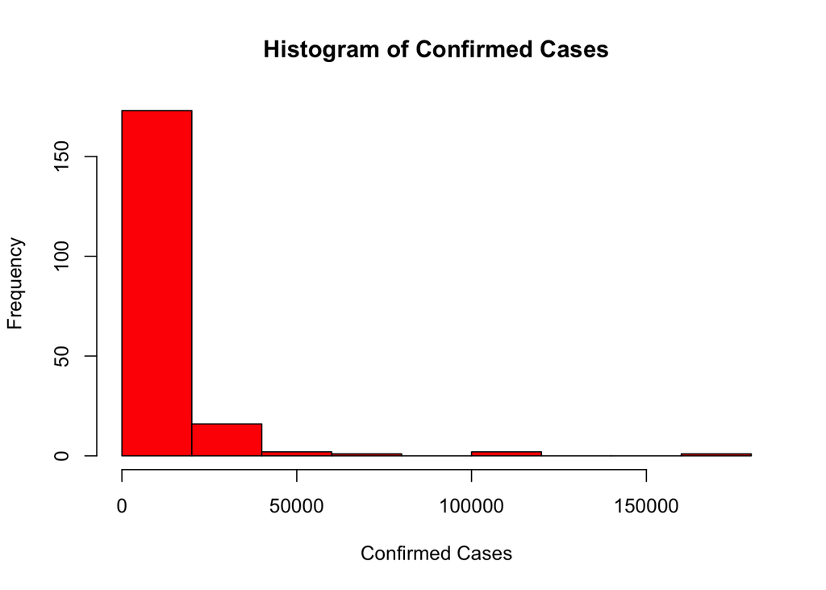

```r
  #type your code here
hist(ma_covid19$`Confirmed cases`, main = "Histogram of Confirmed Cases", xlab = "Confirmed Cases", col = "red")
```

8. **Finally, plot a graph to visually test the hypothesis you propose. Based on the visual evidence, do you see any potential correlation between the two variables? (10%)**

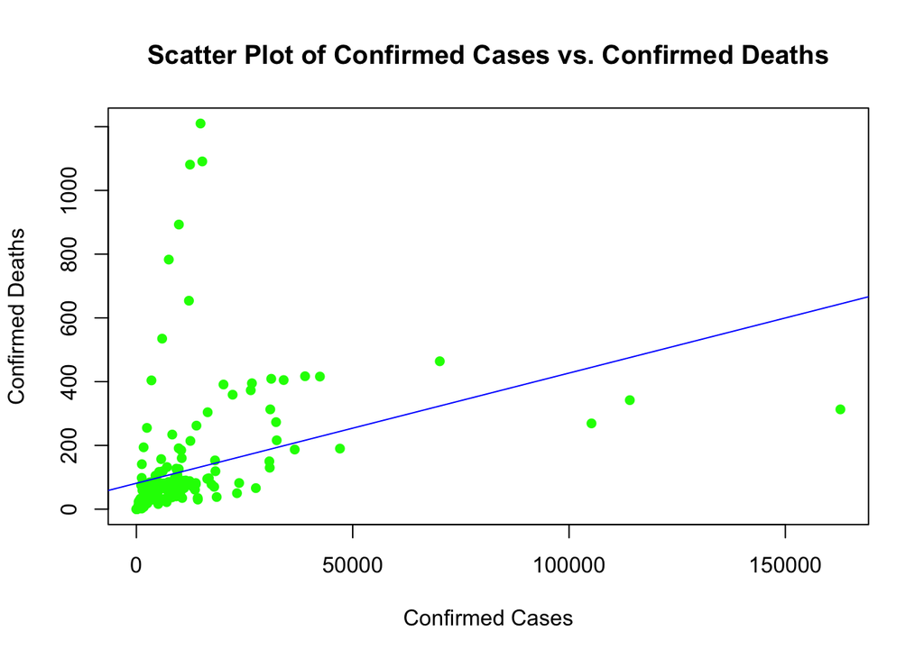

   ```r
   #type your code here
   plot(ma_covid19$`Confirmed cases`, ma_covid19$`Confirmed deaths`,
    main = "Scatter Plot of Confirmed Cases vs. Confirmed Deaths",
    xlab = "Confirmed Cases", ylab = "Confirmed Deaths", pch = 16, col = "green")

   abline(lm(`Confirmed deaths` ~ `Confirmed cases`, data = ma_covid19), col = "blue")
   ```

   ```r
   cor(ma_covid19$`Confirmed cases`, ma_covid19$`Confirmed deaths`)
   ```

   ```
   [1] 0.3358605
   ```

The scatter plot visually displays the relationship between confirmed cases and confirmed deaths. From the scatter plot, we could see that data is scattered and right skewed as seen from the histogram. Further, The positive correlation coefficient suggests a weak positive linear relationship between the number of confirmed COVID-19 cases and the number of confirmed deaths in Massachusetts. As the number of confirmed cases increases, there is a tendency for the number of confirmed deaths to also increase. However, the correlation is not very strong (correlation coefficient around 0.336), indicating that other factors may contribute to the number of deaths.

## Part 2. Reviewing the findings of a graph by examining the raw data. (50%)

1. **Please briefly describe the major findings of this graph. (5%)**

Overall for all countries (except Netherland - above 50% for the 30s generation, and about 30% for the 80s generation ) we could say, there is a decline in the proportion of population above 70% of the 30s generation to less than 50% of the 80s generation (except Sweden).

2. **Your client is concerned about the findings of this graph.** On the one hand, they are surprised and worried by the “crisis of democracy” presented in this graph.**On the other hand, they also doubt the argument of the NYT article and the validity of the findings of this graph.** Before deciding on making any policy to respond, they ask you to conduct some additional research with the original data.

   (1) Read the provided WVS data. The dataset is large, so you must subset it before analyzing it. **Please keep only the following columns: respondents’ country(V2), age(V236), and the question for plotting (V162).** You also need to filter only the observations in the six countries mentioned above: Sweden, Australia, Netherlands, United States, New Zealand, and Britain/United Kingdom. **(10%)**

   Note: all the columns, including those that are measured categorically, are represented by numbers. You must check out the WVS5 codebook to identify what the numerical values mean (especially for V2-country, see p57 of the codebook).

   ```r
   #type your code here
   wvs_data <- read_rds("WVS5.rds")
    wvs_data <- wvs_data |>
     select(V2, V236, V162)|>
     filter(V2 %in% c(752, 554, 36, 528, 840, 826))

   head(wvs_data)
   ```

   | V2 | V236 | V162 |
   | --- | --- | --- |
   | 36 | 1921 | 10 |
   | 36 | 1939 | 10 |
   | 36 | 1954 | 10 |
   | 36 | 1947 | 10 |
   | 36 | 1965 | 9 |
   | 36 | 1980 | 4 |

   (2) Conduct descriptive statistics to show these three columns’ unique values, means, ranges, and numbers of NA. You can plot univariate graphs as we did in challenge#4 or apply the summary statistics function as in challenge#3. Just do either approach. **(10%）**

   ```r
   #type your code here
   summary_stats <- function(x){
     stat <- tibble(
   range=range(x, na.rm = T),
   mean=mean(x, na.rm = T),
   sd=sd(x,na.rm=T),
   na = sum(x < 0), #should be cautious that NA in the dataset is noted as negative numbers.
   unique = length(unique(x))
     )
     return(stat)
   }

   summary_stats(wvs_data$V2)
   ```

   | range | mean | sd | na | unique |
   | --- | --- | --- | --- | --- |
   | 36 | 565.2507 | 298.7867 | 0 | 6 |
   | 840 | 565.2507 | 298.7867 | 0 | 6 |

   ```r
   summary_stats(wvs_data$V236)
   ```

   | range | mean | sd | na | unique |
   | --- | --- | --- | --- | --- |
   | -2 | 1946.526 | 146.0519 | 37 | 80 |
   | 1991 | 1946.526 | 146.0519 | 37 | 80 |

   ```r
   summary_stats(wvs_data$V162)
   ```

   | range | mean | sd | na | unique |
   | --- | --- | --- | --- | --- |
   | -5 | 6.87139 | 4.960539 | 1084 | 14 |
   | 10 | 6.87139 | 4.960539 | 1084 | 14 |

   (3) Now, please plot a graph to show the relationship between the decades of birth (x-axis) and the average level of the response scores to the question “importance of democracy” (y-axis) for each of the six countries. You can use facet_grid or facet_wrap to combine multiple graphs into a matrix of panels. **(15%)**

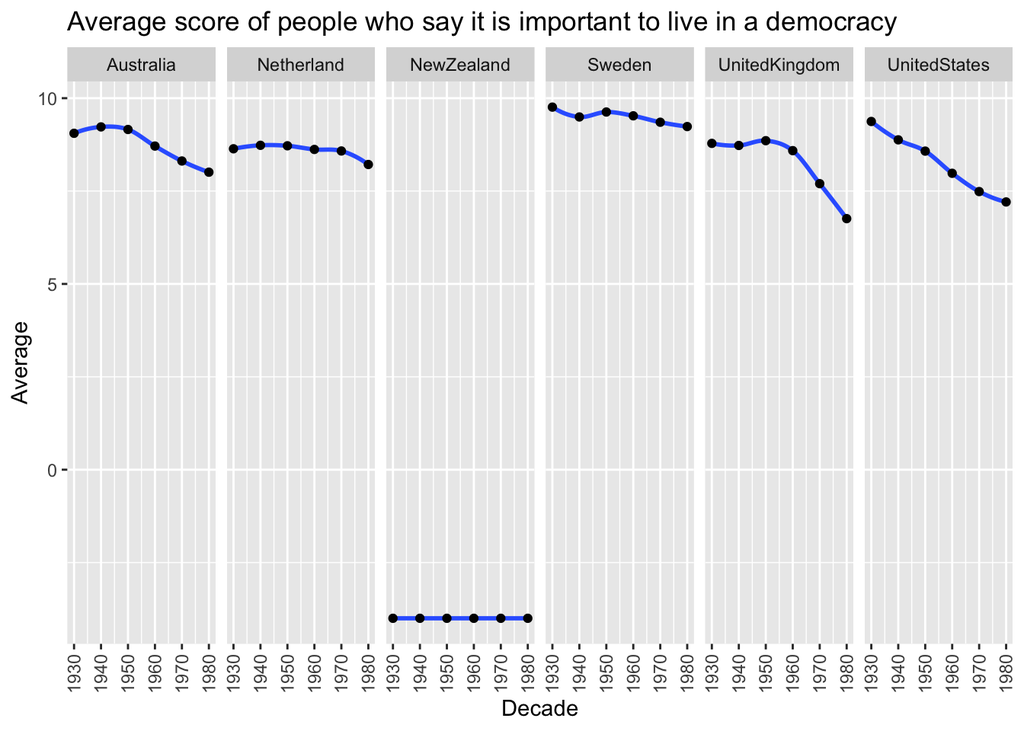

   ```r
   #type your code here
   #type your code here
   library(ggplot2)

   wvs_plot <- wvs_data |>
   mutate(Decade_of_Birth = V236 %/% 10*10,
      dem_importance = as.numeric(V162),
      countries = as.numeric(V2))


   final_plot <- wvs_plot %>%
   group_by(countries, Decade_of_Birth) |>
   summarise(Average = mean(dem_importance)) |>
    mutate(countries = recode(countries,
                      "752" = "Sweden",
                      "554" = "NewZealand",
                      "36"  = "Australia",
                      "528" = "Netherland",
                      "840" = "UnitedStates",
                      "826" = "UnitedKingdom")) |>
   ggplot(aes(x = as.numeric(Decade_of_Birth), y = Average))+
   geom_smooth()+
   geom_point()+
   scale_x_continuous(limits = c(1930,1980))+
   labs(x = "Decade", title = "Average score of people who say it is important to live in a democracy")+
   theme(axis.text.x = element_text(angle = 90, vjust = 0.5, hjust=1))+
   facet_grid(~ countries)
   final_plot
   ```

   Now, lets plot removing `New Zealand` as it has no valid question (because the question was not asked in the country and the data marked it as -4) to answer below questions :

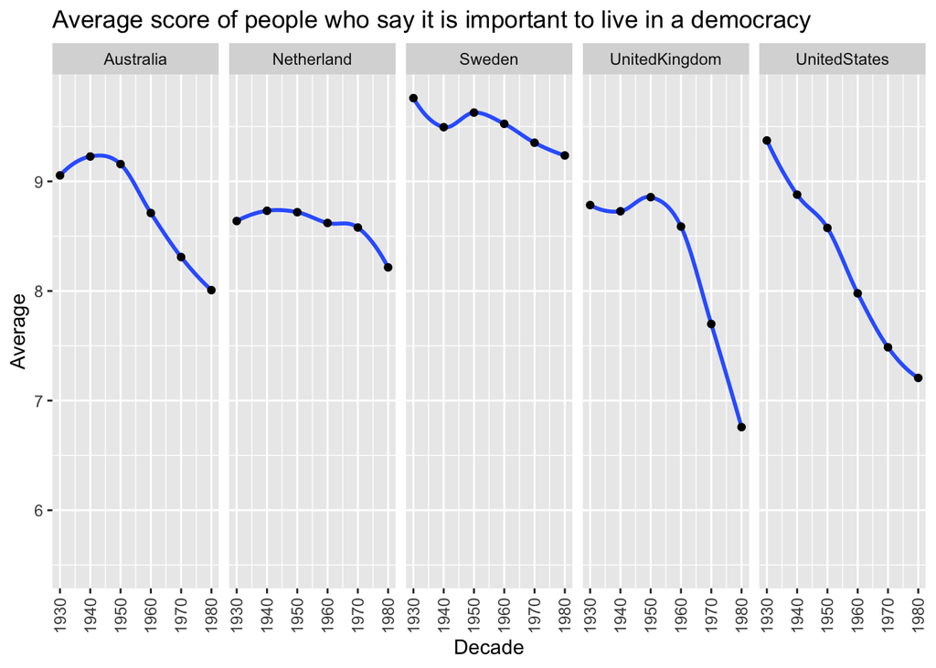

   ```r
     wvs_plot <- wvs_data |>
     filter(V2 %in% c(752, 36, 528, 840, 826))|>
     mutate(Decade_of_Birth = V236 %/% 10*10,
        dem_importance = as.numeric(V162),
        countries = as.numeric(V2))


   wvs_plot %>%
     group_by(countries, Decade_of_Birth) |>
     summarise(Average = mean(dem_importance)) |>
      mutate(countries = recode(countries,
                    "752" = "Sweden",
                    "36"  = "Australia",
                    "528" = "Netherland",
                    "840" = "UnitedStates",
                    "826" = "UnitedKingdom")) |>
     ggplot(aes(x = as.numeric(Decade_of_Birth), y = Average))+
     geom_smooth()+
     geom_point()+
     scale_x_continuous(limits = c(1930,1980))+
     labs(x = "Decade", title = "Average score of people who say it is important to live in a democracy")+
     theme(axis.text.x = element_text(angle = 90, vjust = 0.5, hjust=1))+
     facet_grid(~ countries)
   ```

3. **Describe what you find from the graph you made above. Compared to the graph on NYT, what’s in common, or what’s different? Please type your answer below. (5%)**

   Ans: Yes, looking into both the graph’s we can conclude that people’s response is declining over the years about the “importance of democracy”. Yes, decline in democracy seems to be concerning. Democracy is often considered a fundamental aspect of a just and equitable society. A decline in its perceived importance may suggest a shift in public attitudes, which could have implications for civic engagement, political participation, and the overall health of democratic institutions. It may be worth exploring the reasons behind this decline and addressing any underlying issues that contribute to it. On the other hand, fluctuations in public opinion are not uncommon, and various factors can influence people’s perceptions at different points in time. It’s essential to critically examine the methodology used in the survey, consider cultural and contextual factors, and assess whether the decline is a temporary trend or a more sustained shift. Additionally, public opinion is dynamic and can be influenced by external events, economic conditions, or political developments.